# Week 4 Problems

Ashley

5/8/2020

## 7.3.4 Problems

1. Explore the distribution of each of the x, y, and z variables in diamonds. What do you learn? Think about a diamond and how you might decide which dimension is the length, width, and depth.

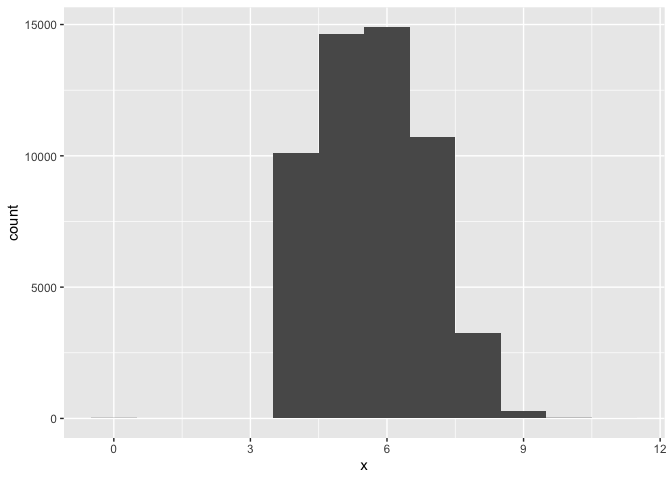

```r
 ggplot(data = diamonds) +
     geom_histogram(mapping = aes(x = x), binwidth =1)
```

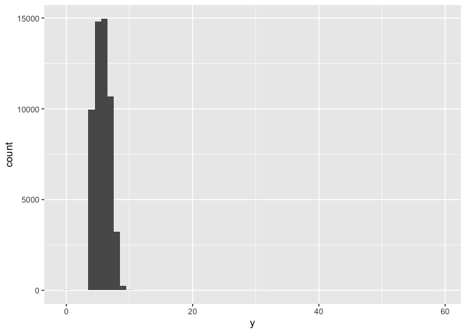

```r
 ggplot(data = diamonds) +
     geom_histogram(mapping = aes(x = y), binwidth = 1)
```

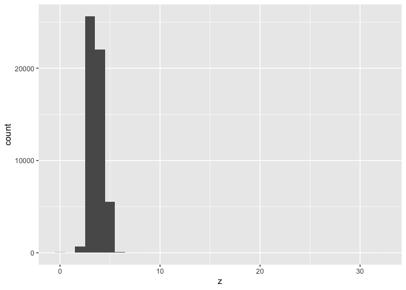

```r
 ggplot(data = diamonds) +
     geom_histogram(mapping = aes(x = z), binwidth =1)
```

```r
filter(diamonds, carat == .99) %>% count()
```

```
## # A tibble: 1 x 1
##       n
##   <int>
## 1    23
```

```r
filter(diamonds, carat == 1) %>% count()
```

```
## # A tibble: 1 x 1
##       n
##   <int>
## 1  1558
```

- There are 23 diamonds that are 0.99 carat and 1,558 diamonds that are 1 carat
- This difference might be because of rounding?
4. Compare and contrast coord_cartesian() vs xlim() or ylim() when zooming in on a histogram. What happens if you leave binwidth unset? What happens if you try and zoom so only half a bar shows?
- When binwidth is unset the function automatically picks a binwidth for you
- When you try to zoom in to half a bar with xlim it cuts out all the other values

## 7.4.1 Problems

1. What happens to missing values in a histogram? What happens to missing values in a bar chart? Why is there a difference?
- The histogram just ignores the missing values, whereas the bar chart creates its own separate category for the NA values
1. What does na.rm = TRUE do in mean() and sum()?
- na.rm ignores missing values when calulating the mean and sum

## 7.5.1.1 Problems

1. Use what you’ve learned to improve the visualisation of the departure times of cancelled vs. non-cancelled flights. **Couldn’t figure out how to get them on the same plot**

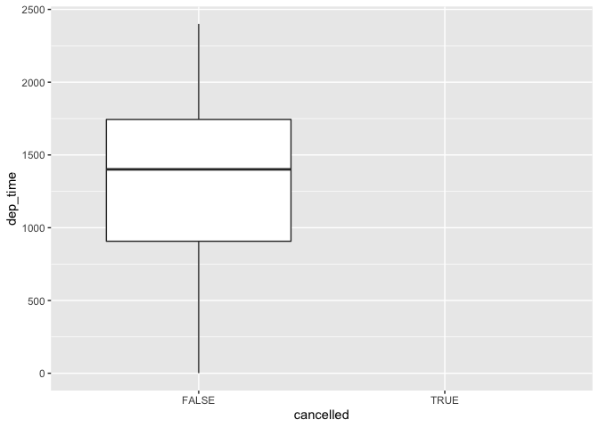

```r
 flights %>%
     mutate(cancelled = is.na(dep_time)) %>%
     ggplot() +
     geom_boxplot(aes(x = cancelled, y = dep_time))
```

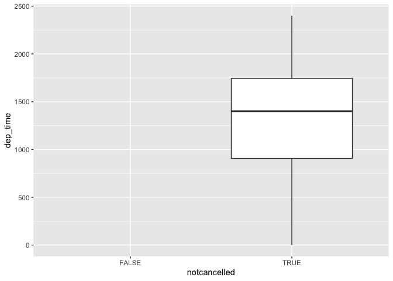

```r
flights %>%
     mutate(notcancelled = !is.na(dep_time)) %>%
     ggplot() +
     geom_boxplot(aes(x = notcancelled, y = dep_time))
```

2. What variable in the diamonds dataset is most important for predicting the price of a diamond? How is that variable correlated with cut? Why does the combination of those two relationships lead to lower quality diamonds being more expensive?

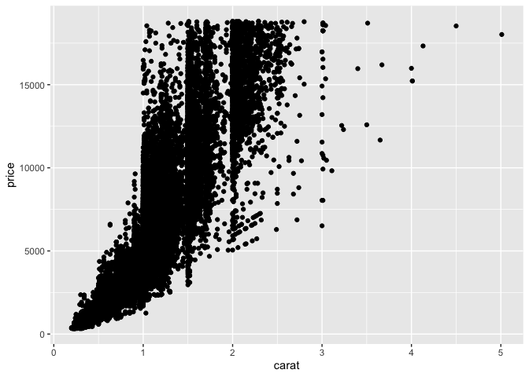

```r
diamonds %>%
    ggplot() +
    geom_point(aes(x = carat, y = price))
```

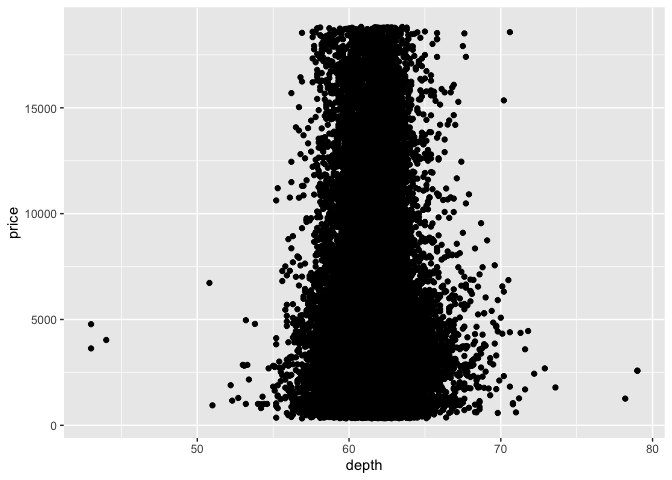

```r
diamonds %>%
    ggplot() +
    geom_point(aes(x = depth, y = price))
```

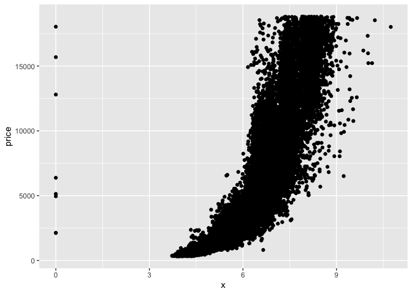

```r
diamonds %>%
    ggplot() +
    geom_point(aes(x = x, y = price))
```

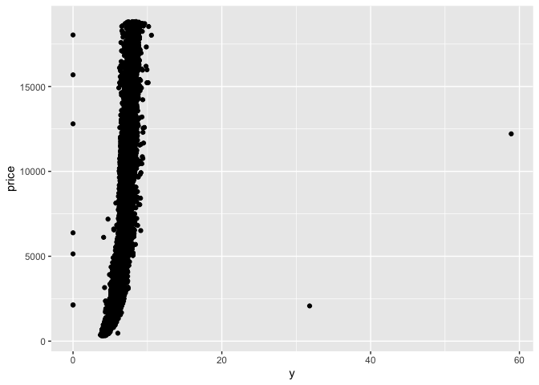

```r
diamonds %>%
    ggplot() +
    geom_point(aes(x = y, y = price))
```

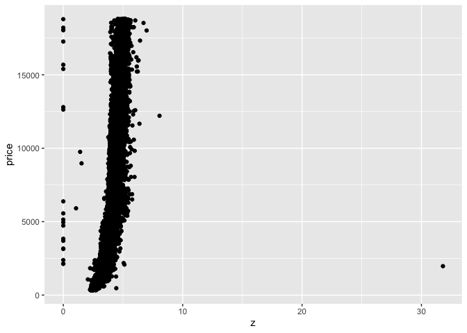

```r
diamonds %>%
    ggplot() +
    geom_point(aes(x = z, y = price))
```

- It looks like carat or length is the most important varable for predicting the price of a diamond since you can see some kind of correlation

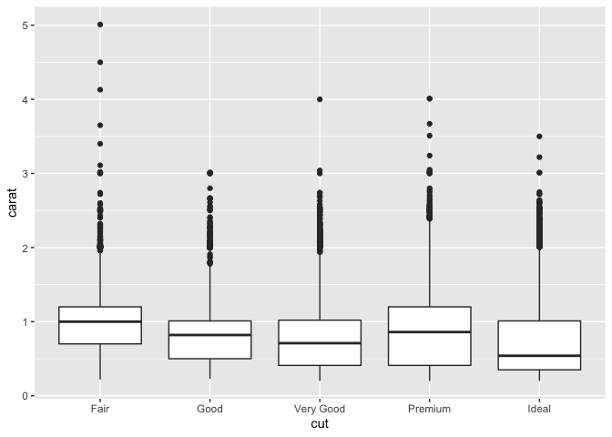

```r
diamonds %>%
    ggplot() +
    geom_boxplot(aes(x = cut, y = carat))
```

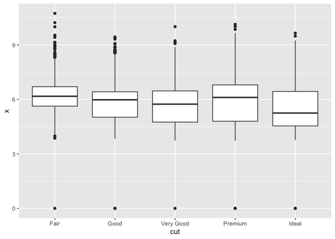

```r
diamonds %>%
    ggplot() +
    geom_boxplot(aes(x = cut, y = x))
```

- It seems like lower quality diamonds can be more expensive because lower quality diamonds have a higher carat value.
3. Install the ggstance package, and create a horizontal boxplot. How does this compare to using coord_flip()?

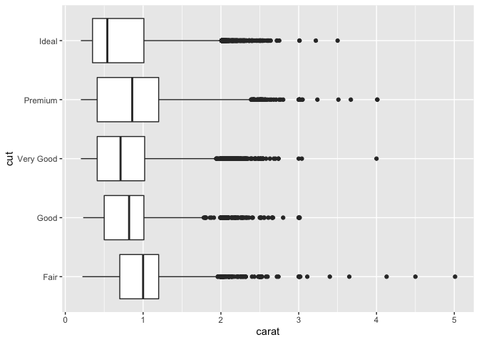

```r
diamonds %>%
    ggplot() +
    geom_boxplot(aes(x = cut, y = carat )) + coord_flip()
```

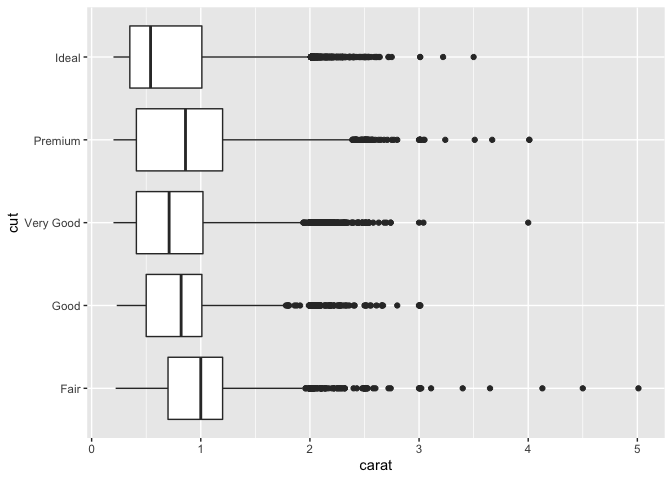

```r
 diamonds %>%
    ggplot() +
   geom_boxploth(aes(x = carat, y = cut ))
```

+ The ggstance horizontal boxplot uses the x variable that is usually the y in coord_flip on the x axis and vice versa, while the coord flip keeps the varibles the same, but literally flips the graph

4. Compare and contrast geom_violin() with a facetted geom_histogram(), or a coloured geom_freqpoly(). What are the pros and cons of each method?

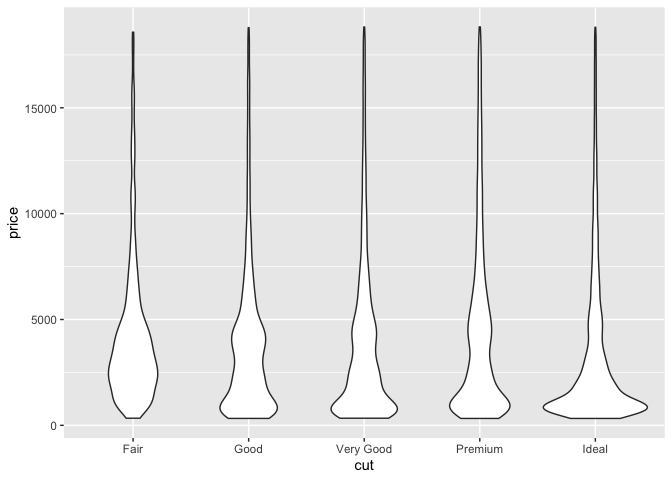

```r
diamonds %>%
  ggplot() +
  geom_violin(aes(x= cut, y = price))
```

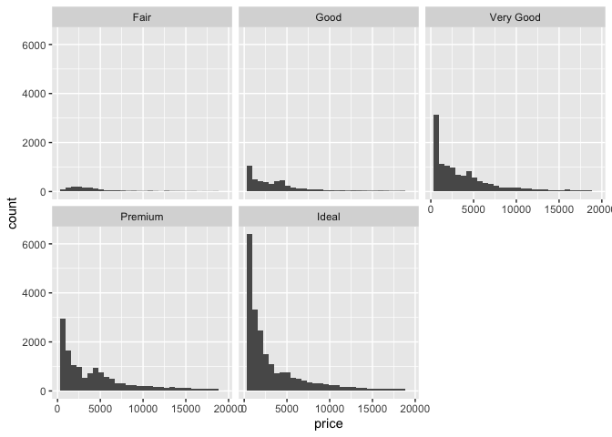

```r
diamonds %>%
     ggplot() +
  geom_histogram(aes(x = price)) +
  facet_wrap(~cut)
```

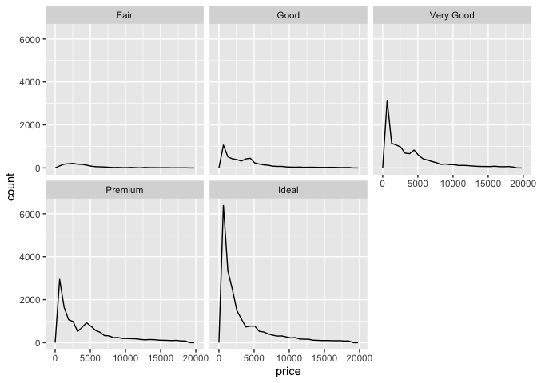

```r
diamonds %>%
  ggplot() +
  geom_freqpoly(aes(x= price)) +
  facet_wrap(~cut)
```

5. If you have a small dataset, it’s sometimes useful to use geom_jitter() to see the relationship between a continuous and categorical variable. The ggbeeswarm package provides a number of methods similar to geom_jitter(). List them and briefly describe what each one does.

## Hypothetical Experiment

- Categorical Variables
  - Analyze the covariation in eye color and hair color
  - Record eye color and hair color of individuals within a defined population
- Continuous Variables
  - Analyze the covariation between height and the number of seeds a plant produces
  - Grow plants of the same genotype in identical environments
  - Record heights of plants and the number of seeds produced by each plant